# Untitled

Mayada Kazem

22/07/2020

```r
# Removing all list objects from ls workspace before we start our work
rm(list=ls())
library(ISwR)
library(zoo)
library(PerformanceAnalytics)
```

```r
library(ggplot2)
library(dplyr)
library(SnowballC)
library(NLP)
library(tm)
library(text2vec)
library(textstem)
library(SimilaR)
library(SentimentAnalysis)
library(class)
library(gmodels)
library(forecast)
library(tidytext)
library(tidyr)
library(tidyverse)
```

# Initial Analysis

```r
stock_data <- read.csv("C:/Users/WATERTON/Desktop/Mayada/Stock_Data.csv", header = TRUE, stringsAsFactors = FALSE)
head(stock_data)
```

```
##         Date     Open     High      Low    Close    Volume Adj.Close
## 1 2016-07-01 17924.24 18002.38 17916.91 17949.37  82160000  17949.37
## 2 2016-06-30 17712.76 17930.61 17711.80 17929.99 133030000  17929.99
## 3 2016-06-29 17456.02 17704.51 17456.02 17694.68 106380000  17694.68
## 4 2016-06-28 17190.51 17409.72 17190.51 17409.72 112190000  17409.72
## 5 2016-06-27 17355.21 17355.21 17063.08 17140.24 138740000  17140.24
## 6 2016-06-24 17946.63 17946.63 17356.34 17400.75 239000000  17400.75
```

Let’s see the stock dataset in more detail

```r
stock_data$Date <- as.Date(stock_data$Date)

str(stock_data)
```

```
## 'data.frame':    1989 obs. of  7 variables:
##  $ Date     : Date, format: "2016-07-01" "2016-06-30" ...
##  $ Open     : num  17924 17713 17456 17191 17355 ...
##  $ High     : num  18002 17931 17705 17410 17355 ...
##  $ Low      : num  17917 17712 17456 17191 17063 ...
##  $ Close    : num  17949 17930 17695 17410 17140 ...
##  $ Volume   : int  82160000 133030000 106380000 112190000 138740000 239000000 98070000 89440000 85130000 99380000 ...
##  $ Adj.Close: num  17949 17930 17695 17410 17140 ...
```

```r
class(stock_data)
```

```
## [1] "data.frame"
```

```r
colnames(stock_data)
```

```
## [1] "Date"      "Open"      "High"      "Low"       "Close"     "Volume"
## [7] "Adj.Close"
```

```r
head(stock_data)
```

```
##         Date     Open     High      Low    Close    Volume Adj.Close
## 1 2016-07-01 17924.24 18002.38 17916.91 17949.37  82160000  17949.37
## 2 2016-06-30 17712.76 17930.61 17711.80 17929.99 133030000  17929.99
## 3 2016-06-29 17456.02 17704.51 17456.02 17694.68 106380000  17694.68
## 4 2016-06-28 17190.51 17409.72 17190.51 17409.72 112190000  17409.72
## 5 2016-06-27 17355.21 17355.21 17063.08 17140.24 138740000  17140.24
## 6 2016-06-24 17946.63 17946.63 17356.34 17400.75 239000000  17400.75
```

The project dataset has financial daily data; i.e., every business day we have a row and for the weekend we don’t have data. This is considered irregular dataset and ts function (used to create time series object) won’t work; frequency argument can’t be defined. Hence, creating zoo object. (Zeilei’s Ordered Observations) object.

```r
# Create a zoo object to explore the data and plot time series graphs

stockdata_zoo <- zoo(stock_data, order.by = stock_data$Date)
str(stockdata_zoo)
```

```
## 'zoo' series from 2008-08-08 to 2016-07-01
##   Data: chr [1:1989, 1:7] "2008-08-08" "2008-08-11" "2008-08-12" "2008-08-13" ...
##  - attr(*, "dimnames")=List of 2
##   ..$ : NULL
##   ..$ : chr [1:7] "Date" "Open" "High" "Low" ...
##   Index:  Date[1:1989], format: "2008-08-08" "2008-08-11" "2008-08-12" "2008-08-13" "2008-08-14" ...
```

```r
DJIA_Close_zoo = zoo(x=stock_data$Adj.Close, order.by = stock_data$Date)
class(DJIA_Close_zoo)
```

```
## [1] "zoo"
```

```r
str(DJIA_Close_zoo)
```

```
## 'zoo' series from 2008-08-08 to 2016-07-01
##   Data: num [1:1989] 11734 11782 11642 11533 11616 ...
##   Index:  Date[1:1989], format: "2008-08-08" "2008-08-11" "2008-08-12" "2008-08-13" "2008-08-14" ...
```

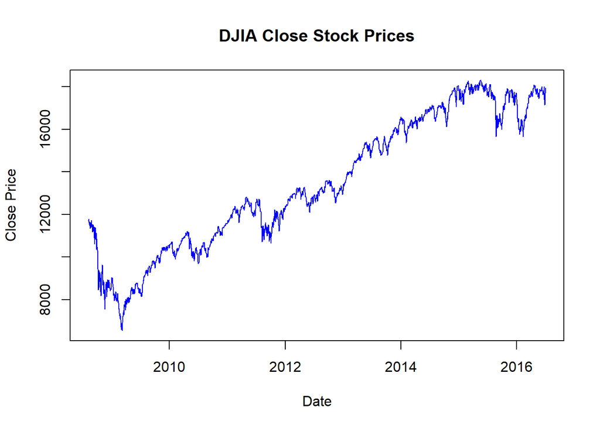

```r
plot(DJIA_Close_zoo, main="DJIA Close Stock Prices", xlab="Date", ylab="Close Price", col = "blue", lty=1)
```

```r
Volume_zoo = zoo(x=stock_data$Volume, order.by = stock_data$Date)
class(Volume_zoo)
```

```
## [1] "zoo"
```

```r
str(Volume_zoo)
```

```
## 'zoo' series from 2008-08-08 to 2016-07-01
##   Data: int [1:1989] 212830000 183190000 173590000 182550000 159790000 215040000 156290000 171580000 144880000 130020000 ...
##   Index:  Date[1:1989], format: "2008-08-08" "2008-08-11" "2008-08-12" "2008-08-13" "2008-08-14" ...
```

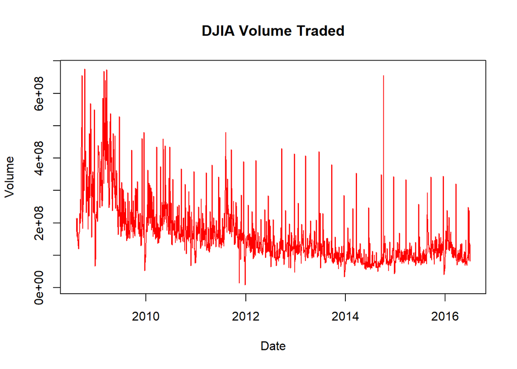

```r
plot(Volume_zoo, main="DJIA Volume Traded", xlab="Date", ylab="Volume", col="red", lty=1)
```

```r
Open_zoo = zoo(x=stock_data$Open, order.by = stock_data$Date)
class(Open_zoo)
```

```
## [1] "zoo"
```

```r
str(Open_zoo)
```

```
## 'zoo' series from 2008-08-08 to 2016-07-01
##   Data: num [1:1989] 11432 11730 11782 11633 11532 ...
##   Index:  Date[1:1989], format: "2008-08-08" "2008-08-11" "2008-08-12" "2008-08-13" "2008-08-14" ...
```

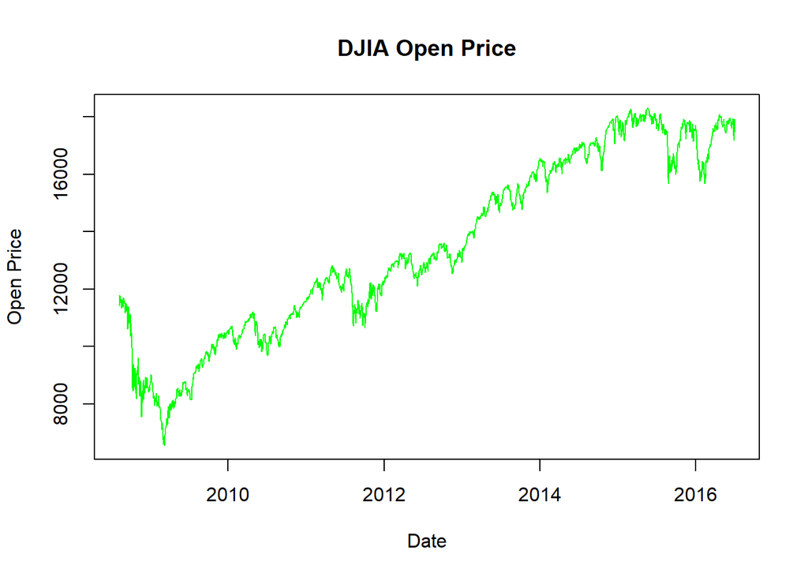

```r
plot(Open_zoo, main="DJIA Open Price", xlab="Date", ylab="Open Price", col="green", lty=1)
```

```r
High_zoo = zoo(x=stock_data$High, order.by = stock_data$Date)
class(High_zoo)
```

```
## [1] "zoo"
```

```r
str(High_zoo)
```

```
## 'zoo' series from 2008-08-08 to 2016-07-01
##   Data: num [1:1989] 11760 11867 11782 11634 11718 ...
##   Index:  Date[1:1989], format: "2008-08-08" "2008-08-11" "2008-08-12" "2008-08-13" "2008-08-14" ...
```

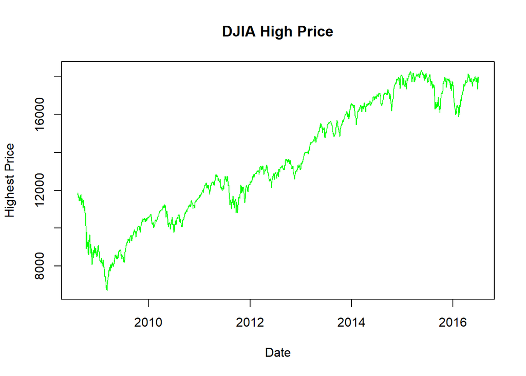

```r
plot(High_zoo, main="DJIA High Price", xlab="Date", ylab="Highest Price", col="green", lty=1)
```

```r
Low_zoo = zoo(x=stock_data$Low, order.by = stock_data$Date)
class(Low_zoo)
```

```
## [1] "zoo"
```

```r
str(Low_zoo)
```

```
## 'zoo' series from 2008-08-08 to 2016-07-01
##   Data: num [1:1989] 11388 11676 11602 11453 11451 ...
##   Index:  Date[1:1989], format: "2008-08-08" "2008-08-11" "2008-08-12" "2008-08-13" "2008-08-14" ...
```

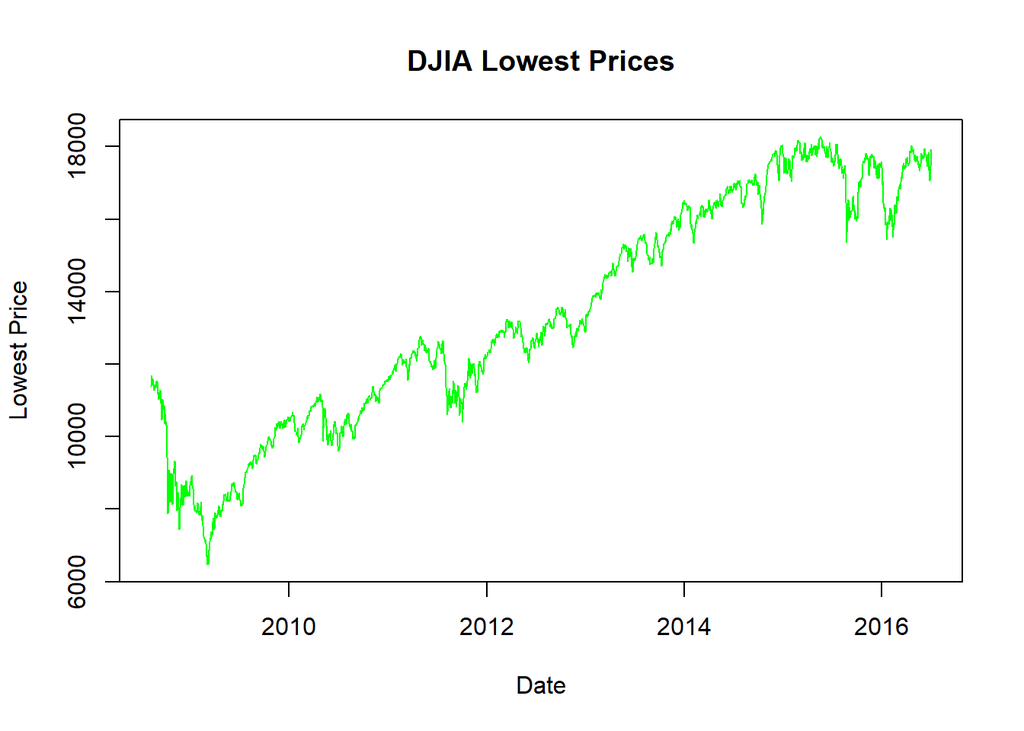

```r
plot(Low_zoo, main="DJIA Lowest Prices", xlab="Date", ylab="Lowest Price", col="green", lty=1)
```

```r
Close_zoo = zoo(x=stock_data$Close, order.by = stock_data$Date)
class(Close_zoo)
```

```
## [1] "zoo"
```

```r
str(Close_zoo)
```

```
## 'zoo' series from 2008-08-08 to 2016-07-01
##   Data: num [1:1989] 11734 11782 11642 11533 11616 ...
##   Index:  Date[1:1989], format: "2008-08-08" "2008-08-11" "2008-08-12" "2008-08-13" "2008-08-14" ...
```

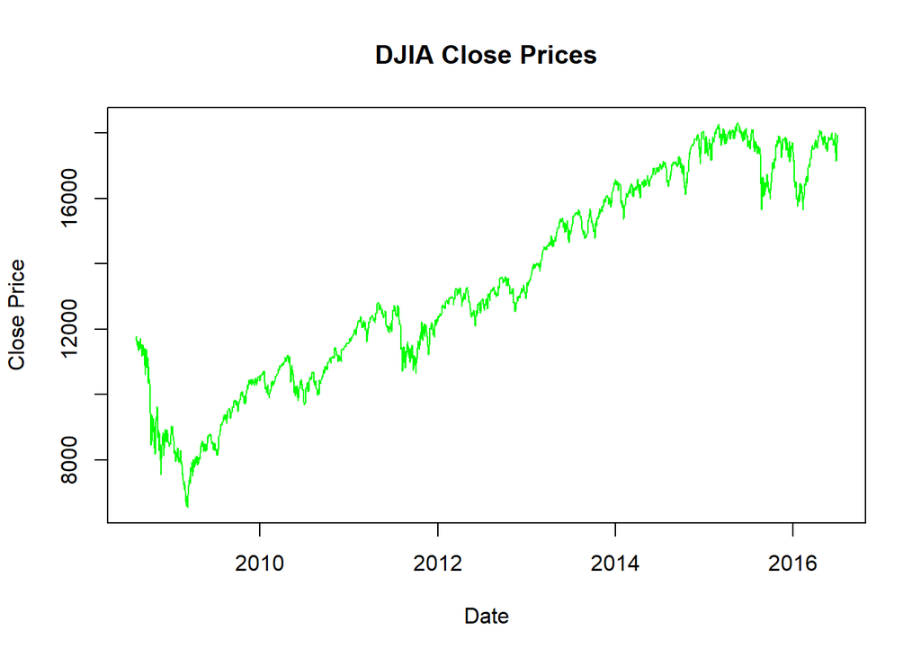

```r
plot(Close_zoo, main="DJIA Close Prices", xlab="Date", ylab="Close Price", col="green", lty=1)
```

```r
# Analyze more stock data file; is it regular? seasonal?

is.regular(stockdata_zoo, strict = TRUE)
```

```
## [1] FALSE
```

```r
is.regular(stockdata_zoo, strict = FALSE)
```

```
## [1] TRUE
```

Stock data is irregular - Hmmmm, why?

```r
# Do we have miising data?

sum(is.na(stockdata_zoo$Date))
```

```
## [1] 0
```

```r
sum(is.na(stockdata_zoo$Open))
```

```
## [1] 0
```

```r
sum(is.na(stockdata_zoo$High))
```

```
## [1] 0
```

```r
sum(is.na(stockdata_zoo$Low))
```

```
## [1] 0
```

```r
sum(is.na(stockdata_zoo$Close))
```

```
## [1] 0
```

```r
sum(is.na(stockdata_zoo$Volume))
```

```
## [1] 0
```

```r
sum(is.na(stockdata_zoo$Adj.Close))
```

```
## [1] 0
```

No missing data.

```r
# Take a look at the data first 6 rows
head(stockdata_zoo)
```

```
##            Date       Open     High     Low      Close    Volume    Adj.Close
## 2008-08-08 2008-08-08 11432.09 11759.96 11388.04 11734.32 212830000 11734.32
## 2008-08-11 2008-08-11 11729.67 11867.11 11675.53 11782.35 183190000 11782.35
## 2008-08-12 2008-08-12 11781.70 11782.35 11601.52 11642.47 173590000 11642.47
## 2008-08-13 2008-08-13 11632.81 11633.78 11453.34 11532.96 182550000 11532.96
## 2008-08-14 2008-08-14 11532.07 11718.28 11450.89 11615.93 159790000 11615.93
## 2008-08-15 2008-08-15 11611.21 11709.89 11599.73 11659.90 215040000 11659.90
```

But missing weekend days / rows, look at above missing weekend rows for 2008-08-09, 2008-08-10

## Data Seasonality

A good way to see if our dataset has seasonality, plot it

[figure not shown]

```r
autoplot.zoo(stockdata_zoo, facets = Series~.)
```

## Univariate Analysis

Measure Mean for all numeric variables; Open, High, Low, Close, Volume, and DJIA Close

```r
# Stock dataset
open_mean <- mean(stock_data$Open)
high_mean <- mean(stock_data$High)
low_mean <- mean(stock_data$Low)
close_mean <- mean(stock_data$Adj.Close)
vol_mean <- mean(stock_data$Volume)
open_mean
```

```
## [1] 13459.12
```

```r
high_mean
```

```
## [1] 13541.3
```

```r
low_mean
```

```
## [1] 13372.93
```

```r
close_mean
```

```
## [1] 13463.03
```

```r
vol_mean
```

```
## [1] 162810970
```

```r
mod_open <- mode(stock_data$Open)
mod_high <- mode(stock_data$High)
mod_low <- mode(stock_data$Low)
mod_close <- mode(stock_data$Adj.Close)
mod_vol <- mode(stock_data$Volume)
mod_open
```

```
## [1] "numeric"
```

```r
mod_high
```

```
## [1] "numeric"
```

```r
mod_low
```

```
## [1] "numeric"
```

```r
mod_close
```

```
## [1] "numeric"
```

```r
mod_vol
```

```
## [1] "numeric"
```

Measure Median for all numeric variables; Open, High, Low, Close, Volume, and DJIA Close

```r
med_open <- median(stock_data$Open)
med_high <- median(stock_data$High)
med_low <- median(stock_data$Low)
med_close <- median(stock_data$Adj.Close)
med_vol <- median(stock_data$Volume)
med_open
```

```
## [1] 13022.05
```

```r
med_high
```

```
## [1] 13088.11
```

```r
med_low
```

```
## [1] 12953.13
```

```r
med_close
```

```
## [1] 13025.58
```

```r
med_vol
```

```
## [1] 135170000
```

Measure Standard Deviation for all numeric variables; Open, High, Low, Close, Volume, and DJIA Close

```r
std_open <- StdDev(stock_data$Open)
std_high <- StdDev(stock_data$High)
std_low <- StdDev(stock_data$Low)
std_close <- StdDev(stock_data$Adj.Close)

std_open
```

```
##            [,1]
## StdDev 3143.282
```

```r
std_high
```

```
##            [,1]
## StdDev 3136.272
```

```r
std_low
```

```
##            [,1]
## StdDev 3150.421
```

```r
std_close
```

```
##            [,1]
## StdDev 3144.007
```

Volume standard deviation measurement is done in MS Excel. R couldn’t handle the big numbers

## Bivariate Analysis

### Volume and ADJ.Close columns graph

```
## [1] "zoo"
```

```
##            DJIA_Close_zoo Volume_zoo
## 2008-08-08       11734.32  212830000
## 2008-08-11       11782.35  183190000
## 2008-08-12       11642.47  173590000
## 2008-08-13       11532.96  182550000
## 2008-08-14       11615.93  159790000
## 2008-08-15       11659.90  215040000
```

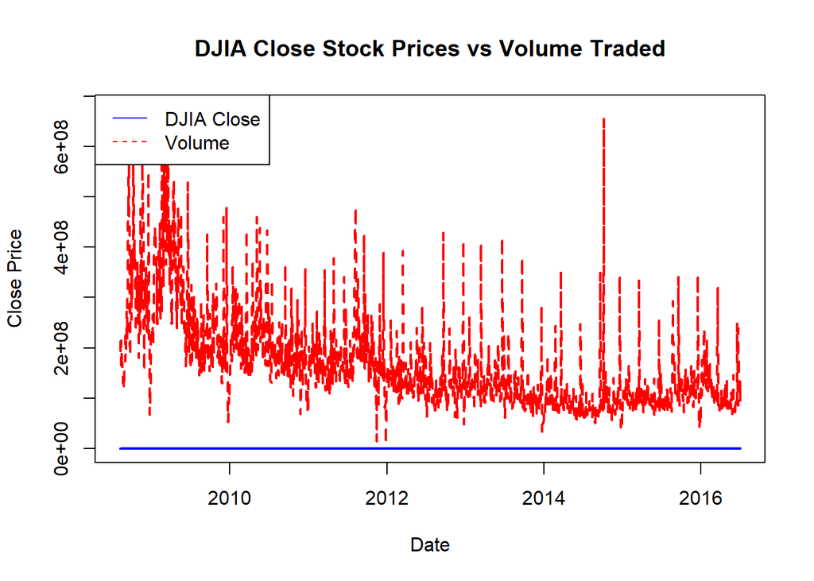

### Volume and Open columns graph

```
## [1] "zoo"
```

```
##            Open_zoo Volume_zoo
## 2008-08-08 11432.09  212830000
## 2008-08-11 11729.67  183190000
## 2008-08-12 11781.70  173590000
## 2008-08-13 11632.81  182550000
## 2008-08-14 11532.07  159790000
## 2008-08-15 11611.21  215040000
```

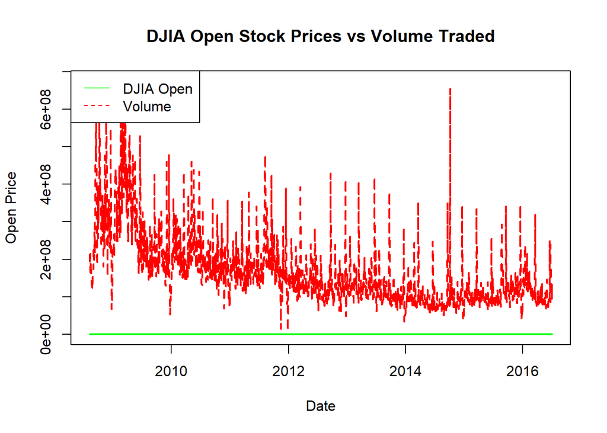

### Volume and High columns graph

```
## [1] "zoo"
```

```
##            High_zoo Volume_zoo
## 2008-08-08 11759.96  212830000
## 2008-08-11 11867.11  183190000
## 2008-08-12 11782.35  173590000
## 2008-08-13 11633.78  182550000
## 2008-08-14 11718.28  159790000
## 2008-08-15 11709.89  215040000
```

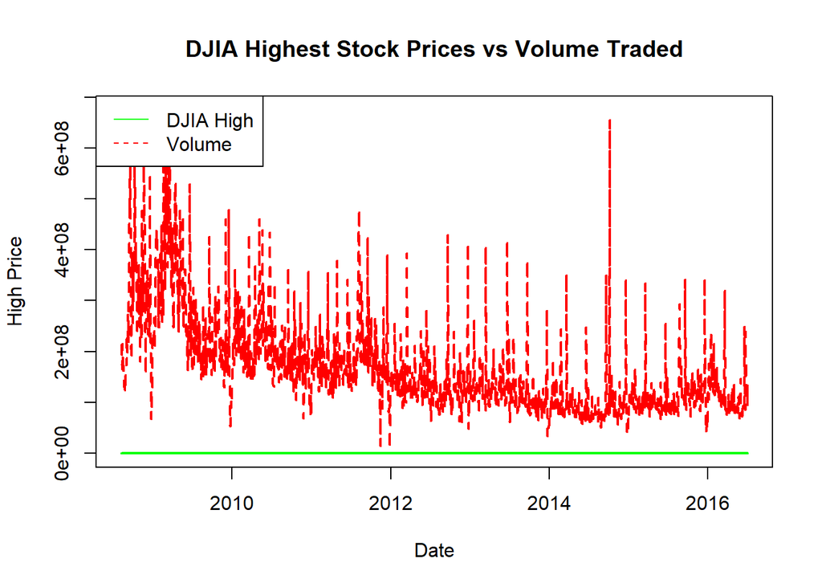

### Volume and Low columns graph

```
## [1] "zoo"
```

```
##             Low_zoo Volume_zoo
## 2008-08-08 11388.04  212830000
## 2008-08-11 11675.53  183190000
## 2008-08-12 11601.52  173590000
## 2008-08-13 11453.34  182550000
## 2008-08-14 11450.89  159790000
## 2008-08-15 11599.73  215040000
```

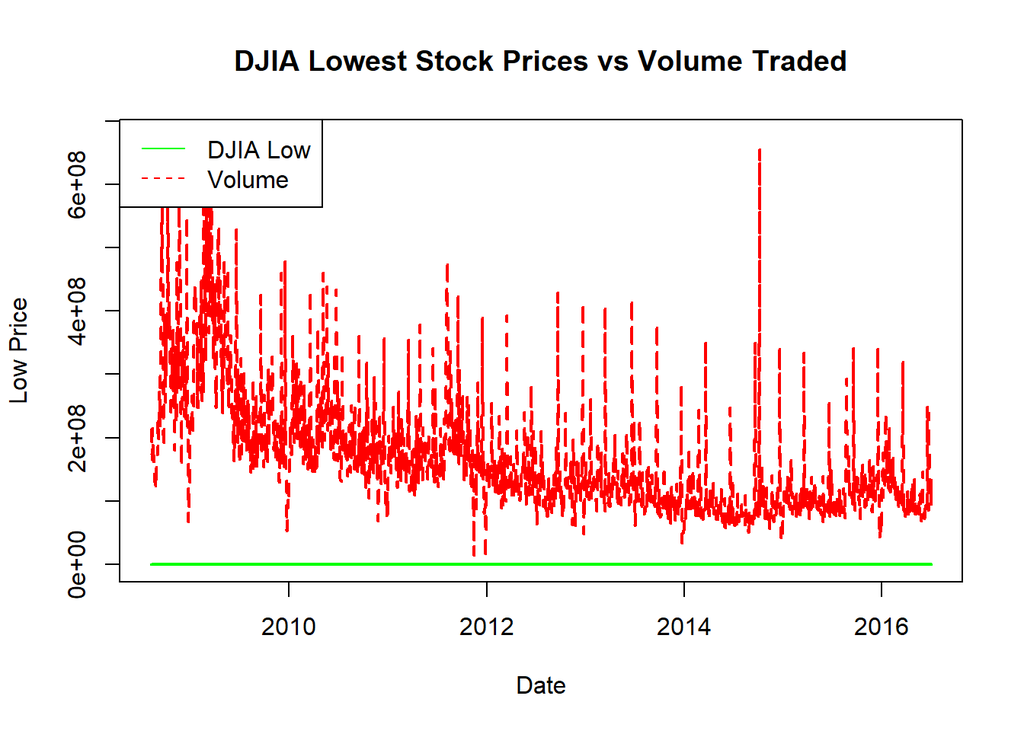

### Adj.Close and Close columns graph

```r
# How about Close column with ADJ.Close column? They seem so similar in description and data values. I'll plot and see

AdjClose_Close_zoo = cbind(DJIA_Close_zoo,Close_zoo)
class(AdjClose_Close_zoo)
```

```
## [1] "zoo"
```

```r
head(AdjClose_Close_zoo)
```

```
##            DJIA_Close_zoo Close_zoo
## 2008-08-08       11734.32  11734.32
## 2008-08-11       11782.35  11782.35
## 2008-08-12       11642.47  11642.47
## 2008-08-13       11532.96  11532.96
## 2008-08-14       11615.93  11615.93
## 2008-08-15       11659.90  11659.90
```

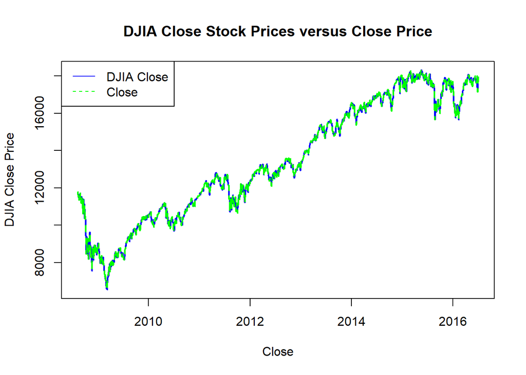

```r
 # plot multiple series at once
 plot(AdjClose_Close_zoo, plot.type="single", col=c("blue","green"), lty=1:2, lwd=2, main="DJIA Close Stock Prices versus Close Price", xlab="Close", ylab="DJIA Close Price")
 legend(x="topleft", legend=c("DJIA Close","Close"), col=c("blue","green"),lty=1:2)
```

From the plot and observing the data, those two columns looks to me identical.

Create data frame for numeric columns without Date to plot

```r
num_stock_data <- data.frame(stock_data$Open, stock_data$High, stock_data$Low, stock_data$Close, stock_data$Volume, stock_data$Adj.Close)
```

When we plot the correlation later, You’ll see that again. Hence, In my analysis, I’ll consider Close column as redundant.

### Analyze data for ouliers

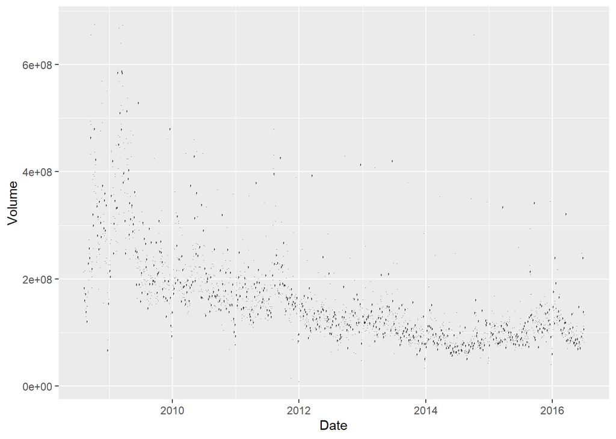

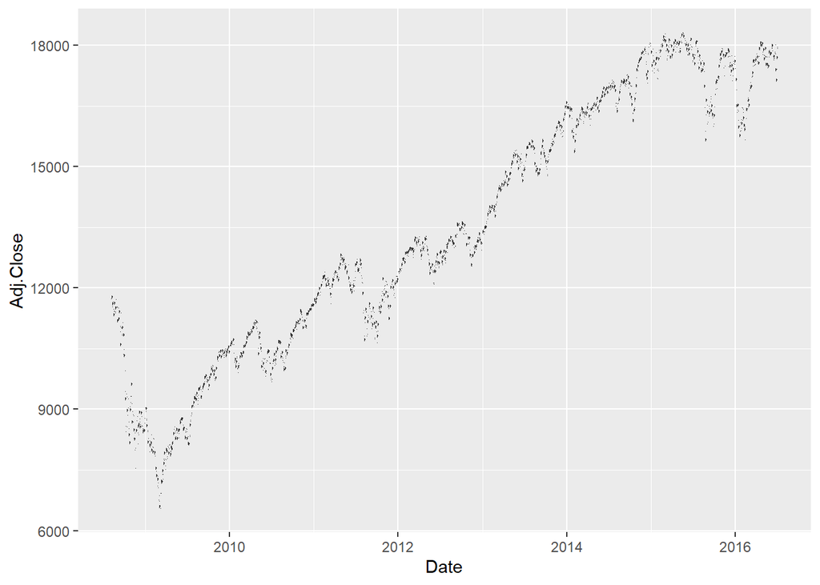

From the above two graphs, I don’t see there are outliers for DJIA Close prices but an incresing trend to DJIA close prices. For Volume column, there are some values that can be considered as ouliers but for the purpose of this project and considering the Label Output Variable is categorial (is either zero or one), I’ll take all values as is.

# Feature Selection

Plotting Stock Dataset Variables Correlation

```r
stock_cor <- cor(num_stock_data)
stock_cor
```

```
##                      stock_data.Open stock_data.High stock_data.Low
## stock_data.Open            1.0000000       0.9995919      0.9994359
## stock_data.High            0.9995919       1.0000000      0.9993728
## stock_data.Low             0.9994359       0.9993728      1.0000000
## stock_data.Close           0.9989909       0.9995456      0.9995952
## stock_data.Volume         -0.6916212      -0.6869967     -0.6995720
## stock_data.Adj.Close       0.9989909       0.9995456      0.9995952
##                      stock_data.Close stock_data.Volume stock_data.Adj.Close
## stock_data.Open             0.9989909        -0.6916212            0.9989909
## stock_data.High             0.9995456        -0.6869967            0.9995456
## stock_data.Low              0.9995952        -0.6995720            0.9995952
## stock_data.Close            1.0000000        -0.6942814            1.0000000
## stock_data.Volume          -0.6942814         1.0000000           -0.6942814
## stock_data.Adj.Close        1.0000000        -0.6942814            1.0000000
```

The above variables are highly correlated columns; values are > 0.99 but not Volume. We can see that Volume is inveresley correlated to Stock Prices attributes

## Visulaize Correlation

To visualize the correlation and read p-values, we can plot this correlation

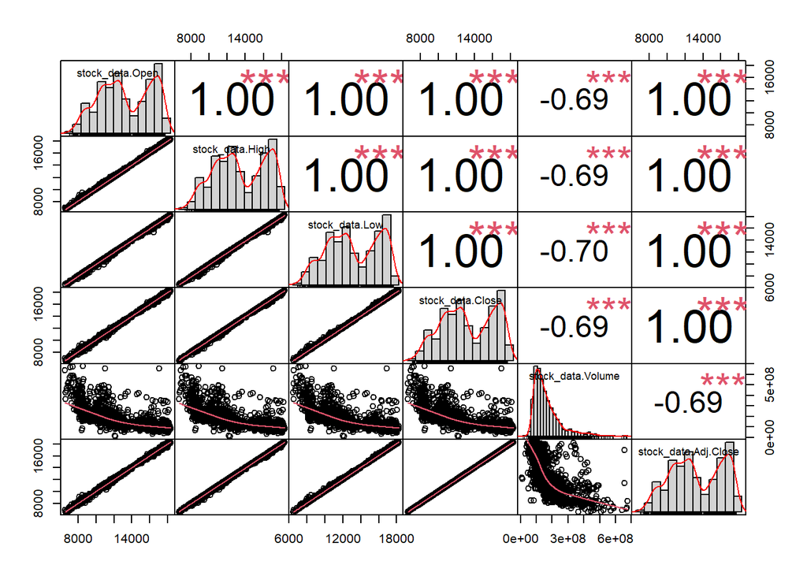

```r
chart.Correlation(num_stock_data, histogram=TRUE, pch=19)
```

DJA.Close column is considered only for prices data anlysis since High, Low, Open, and Close are highliy correlated. Hence those four columns shall be eliminated from our stock data analysis and a new stock data frame shall have three columns only

```r
newstock_df <- data.frame(stock_data$Date, stock_data$Volume, stock_data$Adj.Close)
head(newstock_df)
```

```
##   stock_data.Date stock_data.Volume stock_data.Adj.Close
## 1      2016-07-01          82160000             17949.37
## 2      2016-06-30         133030000             17929.99
## 3      2016-06-29         106380000             17694.68
## 4      2016-06-28         112190000             17409.72
## 5      2016-06-27         138740000             17140.24
## 6      2016-06-24         239000000             17400.75
```

## ARIMA Model

Prepare dataframe for time series prediction. My dataframe is DJIA_Close_zoo (has Date column), use the zoo object (time series object) to perform prediction

```r
# Since auto.arima handles only univariate dataframe, then create it:

head(newstock_df)
```

```
##   stock_data.Date stock_data.Volume stock_data.Adj.Close
## 1      2016-07-01          82160000             17949.37
## 2      2016-06-30         133030000             17929.99
## 3      2016-06-29         106380000             17694.68
## 4      2016-06-28         112190000             17409.72
## 5      2016-06-27         138740000             17140.24
## 6      2016-06-24         239000000             17400.75
```

```r
as.Date(newstock_df$stock_data.Date)
```

[output not shown]

[output cut: 383 more lines]

```r
# change to zoo object and see the first 6 rows:
project_stock_zoo <- zoo(newstock_df, order.by = newstock_df$stock_data.Date)
head(project_stock_zoo)
```

```
##            stock_data.Date stock_data.Volume stock_data.Adj.Close
## 2008-08-08 2008-08-08      212830000         11734.32
## 2008-08-11 2008-08-11      183190000         11782.35
## 2008-08-12 2008-08-12      173590000         11642.47
## 2008-08-13 2008-08-13      182550000         11532.96
## 2008-08-14 2008-08-14      159790000         11615.93
## 2008-08-15 2008-08-15      215040000         11659.90
```

```r
# Create a df of one column for optimum auto.arima function performance:
project_stock_arima <- data.frame(project_stock_zoo$stock_data.Adj.Close)
head(project_stock_arima)
```

```
##            project_stock_zoo.stock_data.Adj.Close
## 2008-08-08                               11734.32
## 2008-08-11                               11782.35
## 2008-08-12                               11642.47
## 2008-08-13                               11532.96
## 2008-08-14                               11615.93
## 2008-08-15                               11659.90
```

### Data Split

Prepare data frame for ARIMA Performance Analytics

```r
# Split ts dataframe to start prediction

#n_st = nrow(project_stock_arima)
#n_st
# For testing; same no. 1989
#train_stock <- round(0.70389 * n_st)
#test_stock <- n_st - train_stock
#nrow(train_stock)
project_stock_arimats <- as.ts(project_stock_arima)
head(project_stock_arimats)
```

```
## Time Series:
## Start = 1
## End = 6
## Frequency = 1
##      project_stock_zoo.stock_data.Adj.Close
## [1,]                                    672
## [2,]                                    678
## [3,]                                    659
## [4,]                                    638
## [5,]                                    656
## [6,]                                    662
```

```r
train_stock_arimats <- project_stock_arimats[1:1400,]
test_stock_arimats <- project_stock_arimats[1401:1989,]
#nrow(train_stock_arimats)
#nrow(test_stock_arimats)
```

Train the ARIMA prediction model

```r
#market_predict_arima_train <- auto.arima(train_stock_arimats, trace = TRUE)
market_predict_arima_train <- auto.arima(train_stock_arimats, trace = TRUE)
```

```
##
##  Fitting models using approximations to speed things up...
##
##  ARIMA(2,1,2) with drift         : 13184.92
##  ARIMA(0,1,0) with drift         : 13194.42
##  ARIMA(1,1,0) with drift         : 13180.07
##  ARIMA(0,1,1) with drift         : 13178.51
##  ARIMA(0,1,0)                    : 13192.92
##  ARIMA(1,1,1) with drift         : 13181.41
##  ARIMA(0,1,2) with drift         : 13180.38
##  ARIMA(1,1,2) with drift         : 13183.37
##  ARIMA(0,1,1)                    : 13177.16
##  ARIMA(1,1,1)                    : 13180.06
##  ARIMA(0,1,2)                    : 13179.04
##  ARIMA(1,1,0)                    : 13178.69
##  ARIMA(1,1,2)                    : 13182.02
##
##  Now re-fitting the best model(s) without approximations...
##
##  ARIMA(0,1,1)                    : 13183.77
##
##  Best model: ARIMA(0,1,1)
```

```r
market_predict_arima_train
```

```
## Series: train_stock_arimats
## ARIMA(0,1,1)
##
## Coefficients:
##           ma1
##       -0.1141
## s.e.   0.0268
##
## sigma^2 estimated as 723.2:  log likelihood=-6589.88
## AIC=13183.76   AICc=13183.77   BIC=13194.25
```

```r
summary(market_predict_arima_train)
```

```
## Series: train_stock_arimats
## ARIMA(0,1,1)
##
## Coefficients:
##           ma1
##       -0.1141
## s.e.   0.0268
##
## sigma^2 estimated as 723.2:  log likelihood=-6589.88
## AIC=13183.76   AICc=13183.77   BIC=13194.25
##
## Training set error measures:
##                     ME   RMSE      MAE        MPE     MAPE      MASE
## Training set 0.5829755 26.873 18.51318 -0.9452393 6.101508 0.9959601
##                      ACF1
## Training set 0.0005194548
```

### Apply the ARIMA algorithm on Test set

```r
market_pred_stockarima_test <- auto.arima(test_stock_arimats)
summary(market_pred_stockarima_test)
```

```
## Series: test_stock_arimats
## ARIMA(1,1,1)
##
## Coefficients:
##          ar1      ma1
##       0.7469  -0.8363
## s.e.  0.1026   0.0840
##
## sigma^2 estimated as 2209:  log likelihood=-3097.27
## AIC=6200.53   AICc=6200.58   BIC=6213.66
##
## Training set error measures:
##                    ME     RMSE      MAE        MPE     MAPE     MASE
## Training set 1.065432 46.88154 34.44916 0.01139863 2.063772 1.000697
##                     ACF1
## Training set -0.02108794
```

```r
# Now let's take the numbers from the auto.arima and understand it more ...
# c is calculated as the mean with difference from the first coefficient (for t-1, from "yesterday")
c_stock = 0.7469 * (1-(-0.8363))
c_stock
```

```
## [1] 1.371532
```

```r
#e(t) is white noise with a standard deviation of sqrt(sd)
e_t_stock = sqrt(2209)
e_t_stock
```

```
## [1] 47
```

```r
# The following equation is the interpretation from auto.arima function
# y_stock(t) = c_stock + 0.7469y(t-1) - 0.8363e(t-1) + e(t_stock)
# y_stock(t) = 1.3715 + 0.7469y(t-1) - 0.8363e(t-1) + 47
# y_stock(t) = 48.3715 + 0.7469y(t-1) - 0.8363e(t-1)
```

### Plot the ARIMA Prediction Test Model

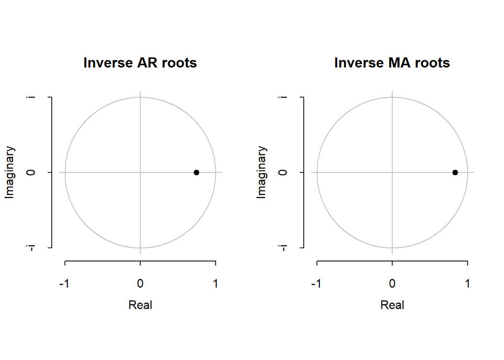

```r
plot(market_pred_stockarima_test)
```

We understood stock dataset and sensed the market performance and how the moving average market can provide more insight to DJIA perofrmance. To add another independent variable that may/may not impact on predicting market performance, this project shall analyze sentiments of texts from Reddit News Headlines. Hence, a new data file is created having the Top1 to Top25 texts with output variable Label. Based on DJIA Close price from yesterday, when it is up or the same (compared from t-1 to t), Label = 1 and when DJIA Close was down, Label = 0. This data file is called Combined data.

```r
library(forecast)
futureVal <- forecast(market_pred_stockarima_test)
futureVal
```

```
##     Point Forecast    Lo 80    Hi 80    Lo 95    Hi 95
## 590       1880.514 1820.279 1940.748 1788.393 1972.635
## 591       1873.428 1791.963 1954.893 1748.839 1998.018
## 592       1868.136 1772.117 1964.155 1721.288 2014.984
## 593       1864.183 1756.916 1971.451 1700.132 2028.235
## 594       1861.231 1744.683 1977.779 1682.987 2039.475
## 595       1859.026 1734.485 1983.567 1668.557 2049.495
## 596       1857.379 1725.739 1989.019 1656.053 2058.705
## 597       1856.149 1718.059 1994.239 1644.958 2067.340
## 598       1855.230 1711.178 1999.282 1634.922 2075.538
## 599       1854.544 1704.910 2004.178 1625.698 2083.390
```

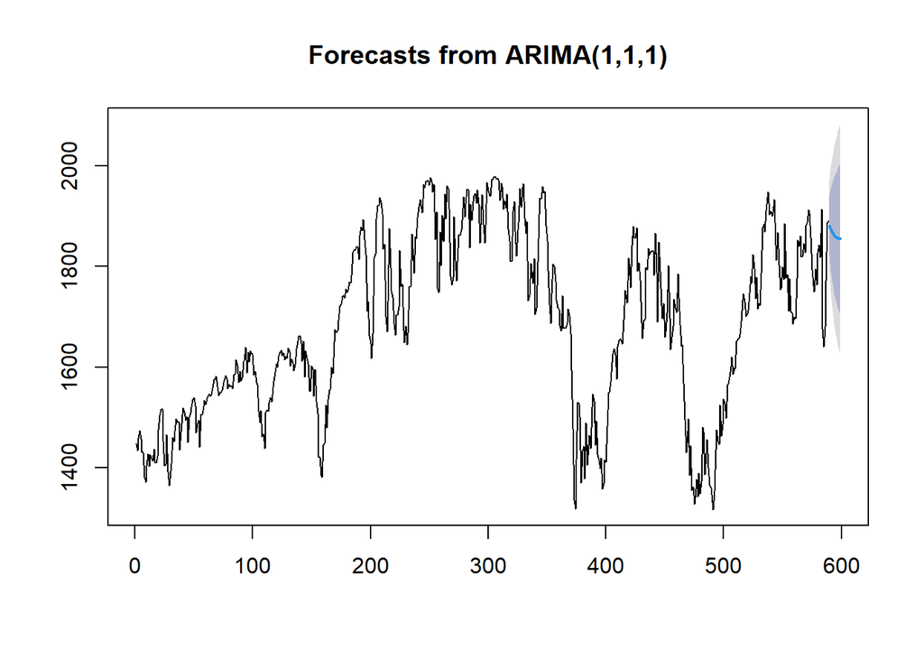

```r
plot(futureVal)
```

# Evaluate the Model

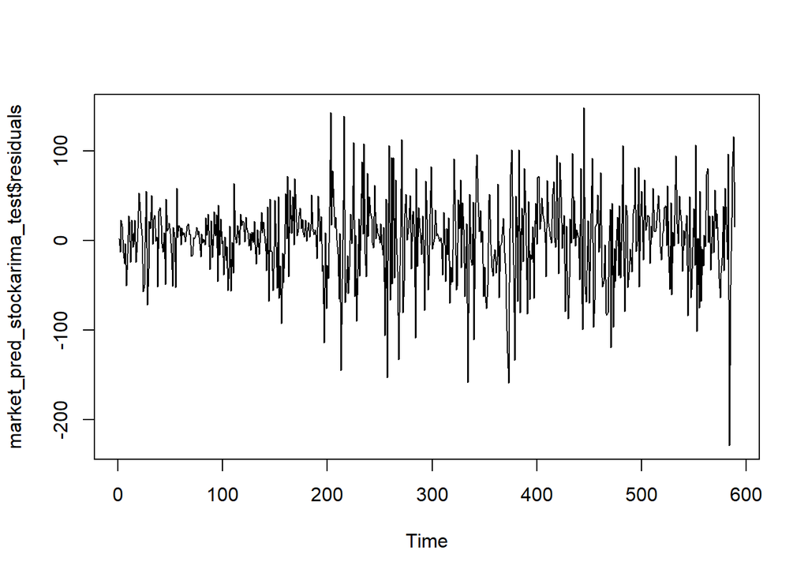

```r
plot(market_pred_stockarima_test$residuals)
```

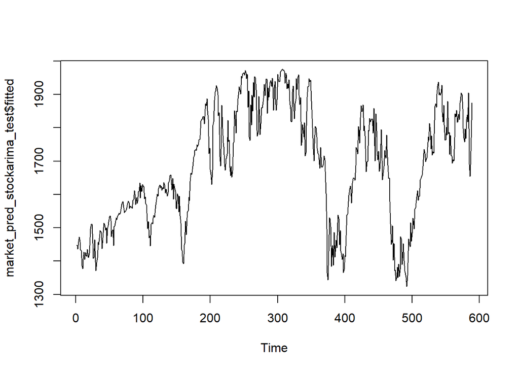

```r
plot(market_pred_stockarima_test$fitted)
```

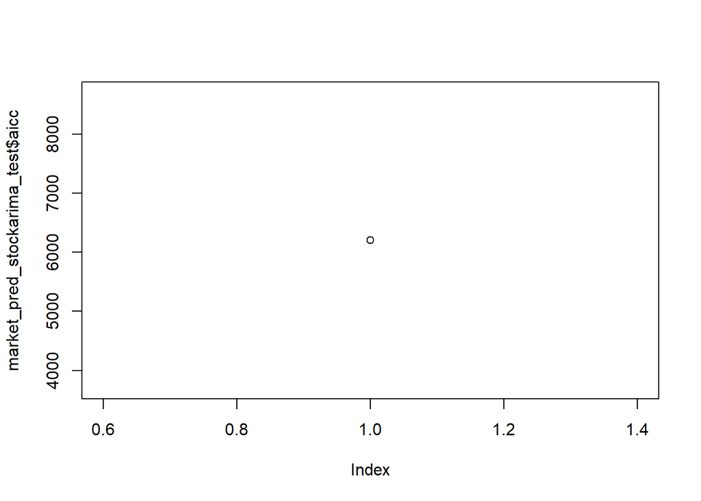

```r
plot(market_pred_stockarima_test$aicc)
```